# how_to_code_in_r.Rmd

Sophia Ungar

2024-01-03

I’m not going to go into why use R, except that it seems to be primarily for statistics. I’m not the best person to ask about R vs other stats languages vs Python. I also want to make this a useful reference guide (mostly for myself), but not a complete teacher.

## Other places to learn things

Suggested by Josh Davidson: [R for Data Science](https://r4ds.hadley.nz/data-visualize)

## Basic Formatting

Outside of the chunks (sorry about the word, not my choice), text is formatted with markdown. About Markdown: https://www.markdownguide.org/

RMarkdown files can be knit to see the final form. Click on the ball of yarn/ Knit button above this. Or click the drop down arrow to choose whether to end up with a pdf, HTML, or Word document.

## Basic Functions

```r
# Arithmetic
2+3
```

```
## [1] 5
```

```r
2-4
```

```
## [1] -2
```

```r
8*9
```

```
## [1] 72
```

```r
5/10
```

```
## [1] 0.5
```

```r
4**10
```

```
## [1] 1048576
```

```r
# Variable Assignment
a <- 2
b = 4

# Print
b
```

```
## [1] 4
```

```r
5
```

```
## [1] 5
```

## Extra code we need

If you haven’t installed the packages first you will need to run install.packages(“”) in the terminal below or go to packages in the bottom right.

```r
library(tidyverse)
```

```r
library(ggplot2) # for the visualizations
```

## Read in data

```r
#data <- read.csv(<filename>.csv) # getting data from a csv
library(palmerpenguins)
data <- penguins
```

We want to pull in data so the computer can look at it. I’ve commented out one way to get it from a csv. To use as an example, the palmerpenguins library has the penguins tibble.

One thing to think about is what kind of structure we want to put the data in. In R there are tables, data frames, tibbles, and more. Some functions work on all of them, but some only work on certain types. TODO: add recommendation on which structure to choose

## Clean Up

Get a specific column with dataset_name$column_name.

```r
flipper <- data$flipper_length_mm
```

Isolate or Remove columns

```r
# same data but only the flipper and bill length columns
flipper_bill <- subset(data, select=c(flipper_length_mm, bill_length_mm))

# same data but without the island and year columns
no_island_year <- subset(data, select=-c(island, year))
```

TODO: add Remove rows with missing data TODO: add find and remove outliers TODO: take the log of everything?

## Summarize

In R there are many ways to do the same thing, in part because it is open source so many different people write the packages that provide a lot of the functions. Below is one way to start looking at the data.

```r
summary(data)
```

```
##       species          island    bill_length_mm  bill_depth_mm
##  Adelie   :152   Biscoe   :168   Min.   :32.10   Min.   :13.10
##  Chinstrap: 68   Dream    :124   1st Qu.:39.23   1st Qu.:15.60
##  Gentoo   :124   Torgersen: 52   Median :44.45   Median :17.30
##                                  Mean   :43.92   Mean   :17.15
##                                  3rd Qu.:48.50   3rd Qu.:18.70
##                                  Max.   :59.60   Max.   :21.50
##                                  NA's   :2       NA's   :2
##  flipper_length_mm  body_mass_g       sex           year
##  Min.   :172.0     Min.   :2700   female:165   Min.   :2007
##  1st Qu.:190.0     1st Qu.:3550   male  :168   1st Qu.:2007
##  Median :197.0     Median :4050   NA's  : 11   Median :2008
##  Mean   :200.9     Mean   :4202                Mean   :2008
##  3rd Qu.:213.0     3rd Qu.:4750                3rd Qu.:2009
##  Max.   :231.0     Max.   :6300                Max.   :2009
##  NA's   :2         NA's   :2
```

```r
head(data) # see the first rows. 6 rows by default
```

```
## # A tibble: 6 × 8
##   species island    bill_length_mm bill_depth_mm flipper_length_mm body_mass_g
##   <fct>   <fct>              <dbl>         <dbl>             <int>       <int>
## 1 Adelie  Torgersen           39.1          18.7               181        3750
## 2 Adelie  Torgersen           39.5          17.4               186        3800
## 3 Adelie  Torgersen           40.3          18                 195        3250
## 4 Adelie  Torgersen           NA            NA                  NA          NA
## 5 Adelie  Torgersen           36.7          19.3               193        3450
## 6 Adelie  Torgersen           39.3          20.6               190        3650
## # ℹ 2 more variables: sex <fct>, year <int>
```

## Basic Stats Functions

```r
mean( data$flipper_length_mm, na.rm=TRUE) # mean, ignoring missing values
```

```
## [1] 200.9152
```

```r
sd( flipper, na.rm=TRUE) # standard deviation, ignoring missing values
```

```
## [1] 14.06171
```

TODO: add confidence intervals

t test

```r
# test only works to compare two levels
# so here we just get Chinstrap and Adelie
chinstrap_adelie <- filter( data, species=="Chinstrap" | species=="Adelie")

# bill length depends on species
t.test(bill_length_mm ~ species, chinstrap_adelie)
```

```
##
##  Welch Two Sample t-test
##
## data:  bill_length_mm by species
## t = -21.865, df = 106.97, p-value < 2.2e-16
## alternative hypothesis: true difference in means between group Adelie and group Chinstrap is not equal to 0
## 95 percent confidence interval:
##  -10.952948  -9.131917
## sample estimates:
##    mean in group Adelie mean in group Chinstrap
##                38.79139                48.83382
```

linear regression

```r
lm(bill_length_mm ~ body_mass_g, data = data)
```

```
##
## Call:
## lm(formula = bill_length_mm ~ body_mass_g, data = data)
##
## Coefficients:
## (Intercept)  body_mass_g
##   26.898872     0.004051
```

ANOVA

```r
summary( aov(bill_length_mm ~ year, data))
```

```
##              Df Sum Sq Mean Sq F value Pr(>F)
## year          1     30   30.24   1.015  0.315
## Residuals   340  10134   29.81
## 2 observations deleted due to missingness
```

## Visualize

This example shows flipper length by bill length. The color is the sex of the bird.

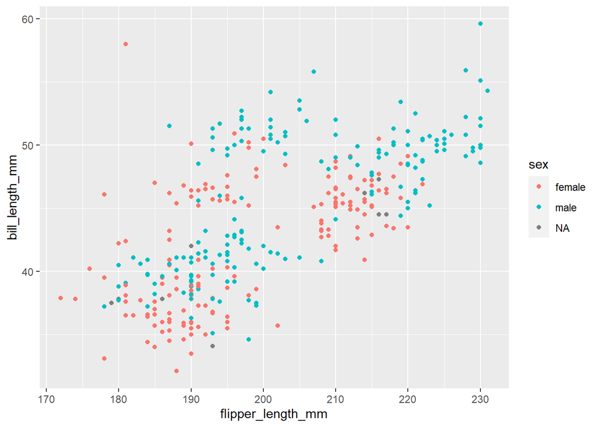

```r
ggplot(data,
       aes(flipper_length_mm, bill_length_mm, color=sex)) +
    geom_point()
```

## Simulate

Simulate from the normal and uniform distributions.

```r
rnorm(n = 10, mean = 100, sd = 20)
```

```
##  [1]  84.39586  54.31364  89.20329  93.36200  96.65557  68.06397 119.09888
##  [8]  99.77178  89.70713  77.04279
```

```r
runif(n = 5, min = 0, max = 1)
```

```
## [1] 0.6746535 0.5093127 0.3248915 0.4044423 0.4456534
```

Bootstrapping I think this was described as a more accurate way to accept or reject the null hypothesis.

```r
library(boot)
set.seed(23) # for replicability

our_function <- function(formula, data, indices) {
  fit <- lm(formula, data[indices,]) # linear regression

  return( summary(fit)$r.square)
}

# bootstrap 10,000 times
# see how much body mass and bill depth explains bill length?
boot_obj <- boot(data = data, statistic = our_function, R=10000, formula = bill_length_mm ~ body_mass_g + bill_depth_mm)

boot_obj
```

```
##
## ORDINARY NONPARAMETRIC BOOTSTRAP
##
##
## Call:
## boot(data = data, statistic = our_function, R = 10000, formula = bill_length_mm ~
##     body_mass_g + bill_depth_mm)
##
##
## Bootstrap Statistics :
##     original      bias    std. error
## t1* 0.356853 0.002327525  0.04308329
```

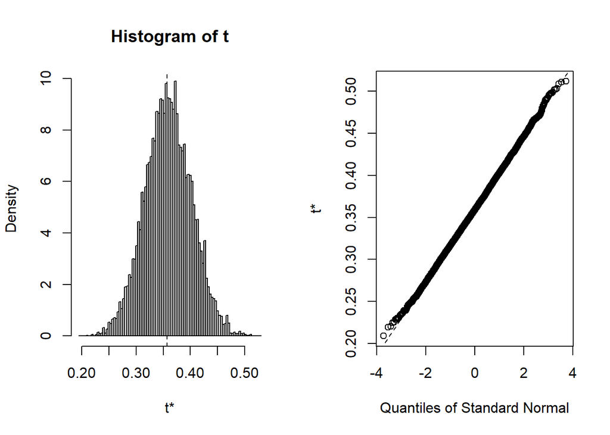

```r
plot(boot_obj)
```

```r
boot.ci(boot_obj, type="bca")
```

```
## BOOTSTRAP CONFIDENCE INTERVAL CALCULATIONS
## Based on 10000 bootstrap replicates
##
## CALL :
## boot.ci(boot.out = boot_obj, type = "bca")
##
## Intervals :
## Level       BCa
## 95%   ( 0.2695,  0.4393 )
## Calculations and Intervals on Original Scale
```

Note that our_function takes in a formula as an argument.

adapted from: https://www.datacamp.com/doc/r/bootstrapping